# Integrated Collision Research

Kaylei Holthe, Yuxin Chen, Bobby Deng, Steven Bao

May 24, 2019

## Introduction

This is an analysis of Seattle collision data, specifically from 2018. The data set includes various details of collisions like places of incidents, people involved and severity of collisions. We are interested in what factors effect collisions the greatest such as time, weather conditions and pedestrian involvement.

## Summary of Project

In 2018 there were 12185 of crashes. There were a total of 14 fatalities. The type of junction with the most incidents in 2018 was Mid-Block (not related to intersection). The total amount of pedestrians involved in car collisions was 571. Tue was the weekday that the most collisions occurred on.

## Summary Table

| Collision Type | Number of Incidents | Number of People | Number of Injuries | Number of Serious Injuries | Fatalities |
| --- | --- | --- | --- | --- | --- |
| Unknown | 2124 | 1772 | 96 | 0 | 1 |
| Angles | 2106 | 5804 | 1218 | 19 | 2 |
| Parked Car | 2033 | 4889 | 223 | 10 | 0 |
| Rear Ended | 1792 | 5136 | 972 | 10 | 0 |
| Other | 1136 | 1909 | 346 | 32 | 1 |
| Sideswipe | 1040 | 2743 | 237 | 5 | 0 |
| Left Turn | 765 | 2084 | 503 | 16 | 1 |
| Pedestrian | 724 | 1638 | 663 | 71 | 9 |
| Right Turn | 179 | 496 | 63 | 2 | 0 |
| Cycles | 149 | 342 | 147 | 19 | 0 |
| Head On | 137 | 402 | 108 | 10 | 0 |

This is a table showing the summary information about all types of collisions in Seattle area in 2018 sorted by the number of total cases. It contains information of the number of people in different levels of injuries or even fatality. We include this table in order to provide clear information on the frequency of each type of collision and its severity from the casualties.

## Map of Collisions

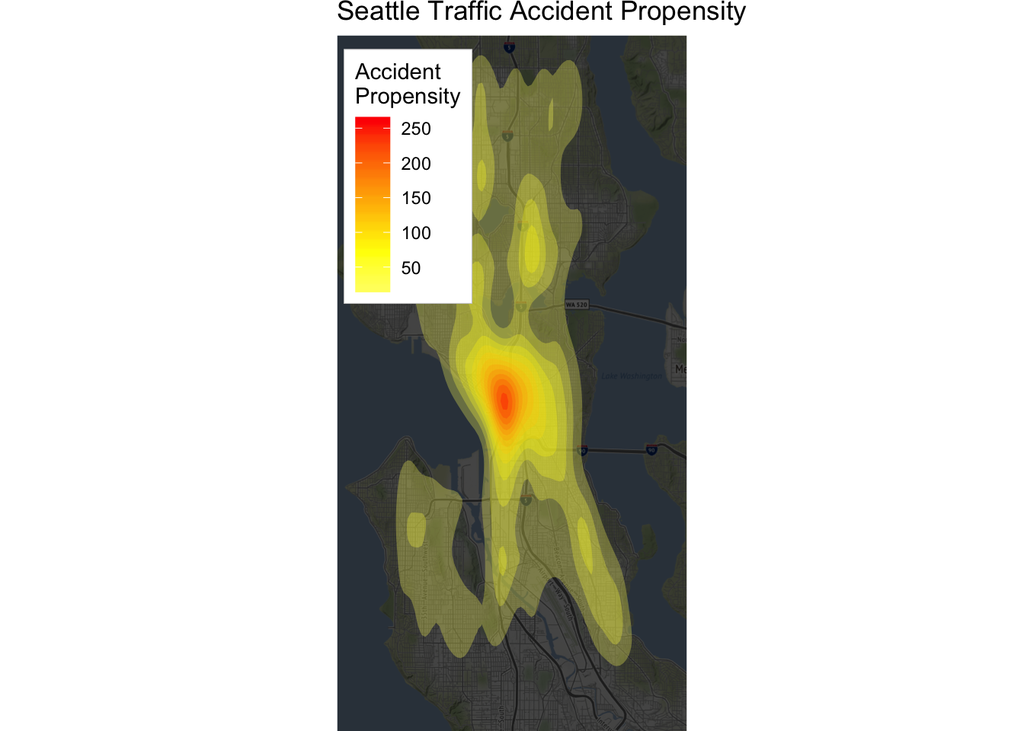

This is a map showing all traffic accidents in the chosen year. And we can see that accidents most happen in downtown area. From the map, we can see the distribution and the propensity of traffic accidents. We include this map in order to give a basic sense about how accidents are distributed in Seattle around 2018.

## Pedestrian and Cyclist Involvement

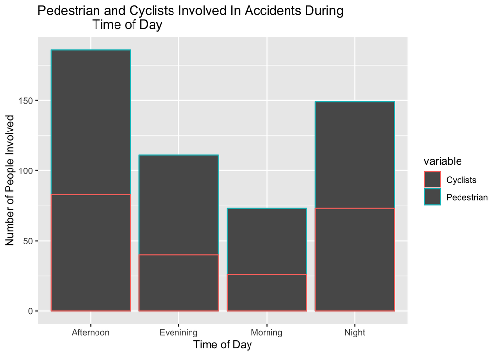

This map visualizes the number of pedestrians and cyclists involved in Seattle car collisions at different times of day.

## Relationships Between Weather Conditions and Fatalities

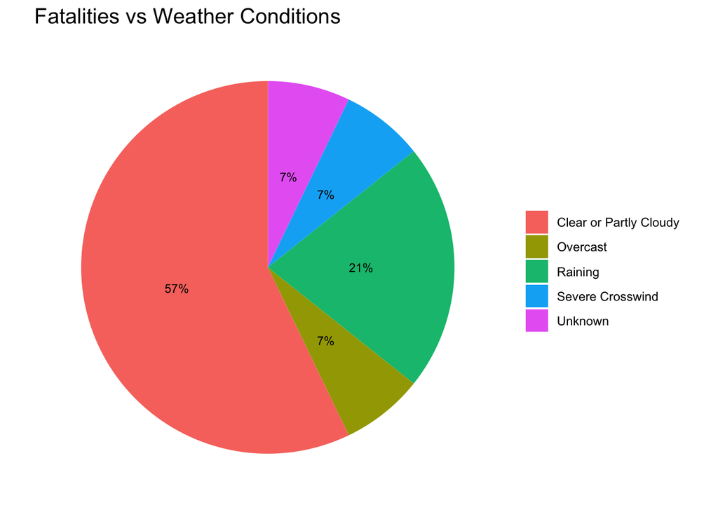

This pie chart shows the fatalities in different weather conditions in Seattle car collisions. From the chart we can see that in “clear or partly cloudy” and “Raining” conditions had the largest amount of fatalities.